# Assignment 4

Question 1:

Preview the document : driver_data.csv.

You are given a dataset of delivery fleet driver data. For each driver we have two features: mean distance driven per day and the mean percentage of time a driver was >5 mph over the speed limit.

Run the K-Means algorithm on this dataset and find the optimal number of clusters. What insights can you gather from these clusters?

Perform Agglomerative clustering on the same dataset with an appropriate number of clusters. Plot the dendrogram.

Compare the results from your K-Means model and your Hierarchical clustering model using silhouette scores. Which model is superior?

# Part 1 :

Run the K-Means algorithm on this dataset and find the optimal number of clusters. What insights can you gather from these clusters?

# Cluster analysis using k means algorithm

To solve this part at very first we will try to understand given dataframe and then we will do very basic feature engineering like scaling which is essential for clustering

Lets first import dataset

```python
#Calling necessary libraries
#Importing pandas for data manipulation

import pandas as pd
import numpy as np
```

```python
##Reading the required data file (which is uploaded in same working directory else we need to \
#give a path)and storing it to d_data by using pandas read_csv() function

d_data=pd.read_csv('driver_data.csv')
```

```python
#Previewing first five rows using head() function to understand what is data about

d_data.head(10)
```

|  | Distance_Feature | Speeding_Feature |
| --- | --- | --- |
| 0 | 71.24 | 28 |
| 1 | 52.53 | 25 |
| 2 | 64.54 | 27 |
| 3 | 55.69 | 22 |
| 4 | 54.58 | 25 |
| 5 | 41.91 | 10 |
| 6 | 58.64 | 20 |
| 7 | 52.02 | 8 |
| 8 | 31.25 | 34 |
| 9 | 44.31 | 19 |

```python
#Checking for missing values

d_data.isnull().sum()
```

```
Distance_Feature    0
Speeding_Feature    0
dtype: int64
```

Now we can use describe() function to understand basic summary statistics of dataframe as we dont have any missing missing values present in our dataset

Describe() function will give us all necessary summary statistics of each column at one place

```python
#Using describe() function to get summary statistics of given data to understand basics \
#of data

d_data.describe()
```

|  | Distance_Feature | Speeding_Feature |
| --- | --- | --- |
| count | 4000.000000 | 4000.000000 |
| mean | 76.041523 | 10.721000 |
| std | 53.469563 | 13.708543 |
| min | 15.520000 | 0.000000 |
| 25% | 45.247500 | 4.000000 |
| 50% | 53.330000 | 6.000000 |
| 75% | 65.632500 | 9.000000 |
| max | 244.790000 | 100.000000 |

Feature 1 is the mean distance driven per day and Feature 2 is the mean percentage of time a driver was >5 mph over the speed limit. Feature 1 and feature 2 have values on a scale 15.52 to 244.79 and 0-100 respectively.

# Scaling

All of the Machine Learning algorithm that are based on some distance based metric, such as Euclidean distance, are adversely affected if the input values are not standardized to a range

# Apply standard scaling on the data.

```python
#Lets import standardscaler class from sklearn preprocessing package
from sklearn.preprocessing import StandardScaler
```

```python
#Fitting given data to standardscaler package and assigning it to std_scale variable
std_scale=StandardScaler().fit(d_data)
```

```python
#Scaled data output is saving to d_data_scaled
d_data_scaled=std_scale.transform(d_data)
```

```python
d_data_scaled[:5,]
```

```
array([[-0.0898104 ,  1.26061251],
       [-0.43977285,  1.04174351],
       [-0.215131  ,  1.18765617],
       [-0.38066642,  0.8228745 ],
       [-0.40142849,  1.04174351]])
```

# K mean clustering:

K-Means clustering is a simple, fast and scalable clustering algorithm that has been widely adopted in many problem domains.

K-Mean is a Hard Clustering method, so in the output of K-Means clustering an observation belongs to only one cluster, and the clusters do not overlap.

This algorithm partitions the data into K number of distinct clusters. We will have to specify the value of K on our own.

Each observation in the output of the K-Means algorithm must belong to one of the K clusters.

It is also known as centroid model or partition-based model. A centroid is the geometric mean of points in a plane.

Run multiple iteration of KMeans algorithm to find an optimal number of clusters using elbow method.

```python
#Importing necessary libraries
from sklearn.cluster import KMeans
import sklearn.cluster as cluster
```

```python
#Creating an empty list and will append the inertia values for different cluster numbers into\
#smae .Here we have select range from 1 to 11 for selecting k
ssq = []

for K in range(1,11):
    kmeans_model = KMeans(n_clusters=K, random_state=1)
    kmeans_model.fit(d_data_scaled)
    ssq.append(kmeans_model.inertia_)
```

# Generate scree plot

There is no general theoretical solution to find the optimal number of cluster for any given dataset.

One way to find the optimal value of K is to compare the resulting SSQ of multiple runs of K-Means algorithm with different K values and choose the best one (having minimum SSQ). We can do this by plotting the K value vs SSQ values and picking the optimal value for K from the graph. This method is called the elbow method, as we look to find a bend or “elbow point” in the graph. Also, the graph is called the Scree plot.

We need to be careful while picking a K value because as K increases, SSQ will keep on decreasing because with more clusters, points will be closer to the centroid.

```python
#Calling libraries required to plot a graph

import matplotlib.pyplot as plt
%matplotlib inline
```

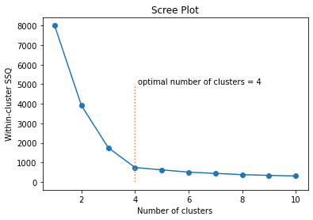

```python
#Plotting a graph.Here X axis is representing number of cluster plotted against resp SSQ on Y axis

plt.plot(range(1,11), ssq, marker='o')
plt.xlabel("Number of clusters")
plt.ylabel("Within-cluster SSQ")
plt.title("Scree Plot")
plt.plot([4]*5000, range(1,5001), ":")
plt.text(4.1, 5000, "optimal number of clusters = 4")
plt.show()
```

From above graph we can say that 4 is optimum number of cluster as at that point we can se elbow

```python
#Calling libraries

import sklearn.metrics as metrics
```

```python
#Verifying optimum number of cluster by using Silhoutte score within range of 3 to 5

for i in range(3,6):
    labels=cluster.KMeans(n_clusters=i,random_state=200).fit(d_data_scaled).labels_
    print ("Silhoutte score for k= "+str(i)+" is "+str(metrics.silhouette_score(d_data_scaled,\
                                                                                labels,metric=\
                                                                                "euclidean",
                                 sample_size=1000,random_state=200)))
```

```
Silhoutte score for k= 3 is 0.7462091485746275
Silhoutte score for k= 4 is 0.7784765551069429
Silhoutte score for k= 5 is 0.7300151533223379
```

From this we'll pick the k value where Silhoutte score is maxiumum .Here its maximum for K=4

From this result we can confirm that FOUR should be the optimal number of clusters for the given data.

Let's fit the KMeans model again with K=4

```python
km = KMeans(n_clusters=4, random_state=123)
km
```

```
KMeans(n_clusters=4, random_state=123)
```

```python
km.fit(d_data_scaled)
```

```
KMeans(n_clusters=4, random_state=123)
```

Make predictions for the clusters of the given dataset.

```python
predicted_cluster = km.predict(d_data_scaled)
```

```python
predicted_cluster[:10]
```

```
array([2, 2, 2, 2, 2, 0, 2, 0, 2, 2], dtype=int32)
```

Plot the data partitioned into clusters.

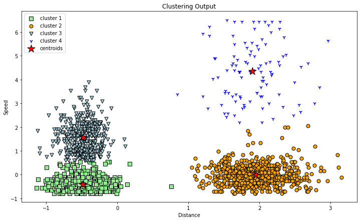

```python
plt.figure(figsize=(12,7))
plt.scatter(d_data_scaled[predicted_cluster==0,0], d_data_scaled[predicted_cluster==0, 1], s=50, c='lightgreen',\
           marker='s', edgecolors='black', label='cluster 1')

plt.scatter(d_data_scaled[predicted_cluster==1,0], d_data_scaled[predicted_cluster==1, 1], s=50, c='orange',\
           marker='o', edgecolors='black', label='cluster 2')

plt.scatter(d_data_scaled[predicted_cluster==2,0], d_data_scaled[predicted_cluster==2, 1], s=50, c='lightblue',\
           marker='v', edgecolors='black', label='cluster 3')

plt.scatter(d_data_scaled[predicted_cluster==3,0], d_data_scaled[predicted_cluster==3, 1], s=50, c='blue',\
           marker='1', edgecolors='black', label='cluster 4')

plt.scatter(km.cluster_centers_[:,0], km.cluster_centers_[:,1], s=250, c='red',\
           marker='*', edgecolors='black', label='centroids')

plt.legend(scatterpoints=1)
plt.xlabel("Distance")
plt.ylabel("Speed")
plt.title("Clustering Output")
plt.show()
```

Cluster 3: Group of drivers with high speed limit cross points and least mean distance drived points

Cluster 4: Group of drivers that have highest number of times speed limit cross points along with maximum daily mean distance covered points

Cluster 1:Group of drivers that have lowest number of times speed limit cross points along with lowest daily mean distance covered points

Cluster 2:Group of drivers that have lowest number of times speed limit cross points along with maximum daily mean distance covered points

Accordingly, an analyst may conclude following labels for each cluster for driver's performance which may decide in :

Cluster 3: Very Poor Cluster 1: Low Cluster 2: Highly Efficient Cluster 4: Moderate We can insert these labels back into our dataset.

```python
#Relebelling the cluster according to their speed and distance feature which will predict their
#performance

predictions_relabelled = np.where(predicted_cluster==0, "Low Performer",np.where(predicted_cluster==1,"Highly Efficient",np.where(predicted_cluster==2, "Very Poor","Moderate")))
d_data['Driver_Performance_category'] = pd.Series(predictions_relabelled, index=d_data.index)
d_data.index.name = "Driver ID"
```

```python
#Looking at data how this clustering has been done by using head() function.
pd.DataFrame(d_data).head(10)
```

| Driver ID | Distance_Feature | Speeding_Feature | Driver_Performance_category |
| --- | --- | --- | --- |
| 0 | 71.24 | 28 | Very Poor |
| 1 | 52.53 | 25 | Very Poor |
| 2 | 64.54 | 27 | Very Poor |
| 3 | 55.69 | 22 | Very Poor |
| 4 | 54.58 | 25 | Very Poor |
| 5 | 41.91 | 10 | Low Performer |
| 6 | 58.64 | 20 | Very Poor |
| 7 | 52.02 | 8 | Low Performer |
| 8 | 31.25 | 34 | Very Poor |
| 9 | 44.31 | 19 | Very Poor |

# Part 2 : Hierarchical Clustering using Scikit-Learn

Q.Perform Agglomerative clustering on the same dataset with an appropriate number of clusters. Plot the dendrogram.

Dataset provided in driver_data.csv file contains information about 4000 delivery fleet drivers.For each driver we have two features: mean distance driven per day and the mean percentage of time a driver was >5 mph over the speed limit.

Apply Hierarchical Clustering to partition the driver into distinct clusters. For this we will use same scaled data which we have used earlier for K-means clustering

Hierarchical clustering is an alternative to K-Means clustering that can yield very different clusters by seeking to build hierarchy of clusters.

• It is a distance-based algorithm that is based on the core idea of objects being more related to nearby objects than to objects farther away.

• This clustering method lends itself to an intuitive graphical display in the form of a tree-based representation of the observations, called a dendrogram, leading to easier interpretation of the clusters.

It doesn’t require us to pre-specify the number of clusters K.

Using Scipy we will first create dendrogram for this dataset.

```python
#Calling hierarchy cluster class from scipy package

from scipy.cluster.hierarchy import linkage, dendrogram
import matplotlib.pyplot as plt
%matplotlib inline
```

Choosing color palette for dendrogram:

Note that this palette is global (i.e., setting it once changes the colors for all subsequent calls to dendrogram) and that it affects only the the colors below color_threshold.

Note that dendrogram also accepts a custom coloring function through its link_color_func keyword, which is more flexible and non-global.

Make dendogram black.

```python
#Selecting black color palette
from scipy.cluster.hierarchy import set_link_color_palette
set_link_color_palette(['black'])
```

The methods that calculate distance between two clusters. and group the clusters, are called Linkage methods. There are 3 such methods:

1.Average linkage method

2.Centroid method

3.Ward method

Out of this we will use Ward method in which clusters that lead to minimum increase in total within-cluster sum of squares are merged.

```python
link = linkage(d_data_scaled, method='ward', metric='euclidean')
```

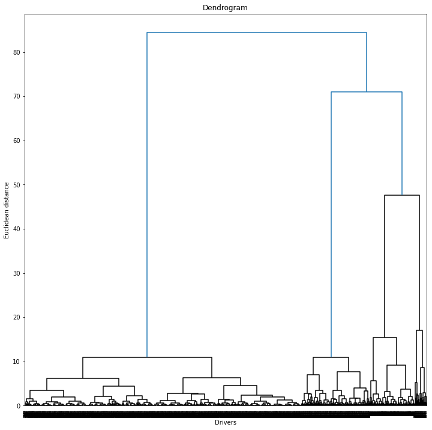

```python
#Plotting a dendrogram

plt.figure(figsize=(12,12))
dnd = dendrogram(link)
plt.title('Dendrogram')
plt.xlabel('Drivers')
plt.ylabel("Euclidean distance")
plt.show()
```

As a rule of thumb, we can cut the dendrogram where the gap between two successive combination similarities is largest. In the above dendogram, we can make this cut for 4 clusters.

Next, we use Scikit-Learn to apply Agglomerative Clustering.

```python
from sklearn.cluster import AgglomerativeClustering
```

```python
model = AgglomerativeClustering(n_clusters=4)
```

Fit the model to our scaled dataset.

```python
model.fit(d_data_scaled)
```

```
AgglomerativeClustering(n_clusters=4)
```

Check out the cluster predictions made by the model for our dataset.

```python
model.labels_
```

```
array([1, 1, 1, ..., 2, 2, 2])
```

Next, we calculate the Silhouette score using Scikit-Learn's metrics class.

```python
from sklearn.metrics import silhouette_score
```

```python
silhouette_score(d_data_scaled, model.labels_)
```

```
0.778897040913367
```

Let's visualize the cluster output.

```python
import seaborn as sns
```

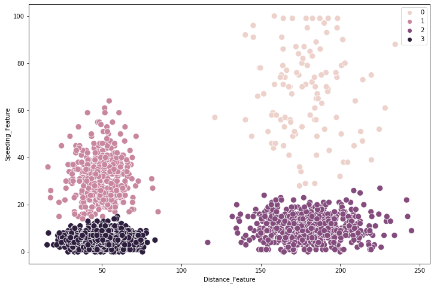

```python
#Plot a graph

plt.figure(figsize=(12,8))
sns.scatterplot(x='Distance_Feature', y='Speeding_Feature', data=d_data, hue=model.labels_, s=100)
plt.show()
```

From the output we see that Delivery fleet drivers performance falls into one of 4 clusters based on his/her Daily distance drived and % number of times his speed was >5mph

# Part 3:Compare the results

Compare the results from your K-Means model and your Hierarchical clustering model using silhouette scores. Which model is superior?

Silhouette analysis can be used to study the separation distance between the resulting clusters. The silhouette plot displays a measure of how close each point in one cluster is to points in the neighboring clusters and thus provides a way to assess parameters like number of clusters visually. This measure has a range of [-1, 1].

Silhouette coefficients (as these values are referred to as) near +1 indicate that the sample is far away from the neighboring clusters

```python
#Silhoutte score for K Means Clustering


Kmean_score = silhouette_score(d_data_scaled, km.labels_, metric='euclidean')

# Print the score

print('Silhouette Score for K means Clustering is: %.5f' % Kmean_score)
```

```
Silhouette Score for K means Clustering is: 0.78437
```

```python
#Silhoutte score for Agglomerative Clustering

Agglo_score=silhouette_score(d_data_scaled, model.labels_)

# Print the score

print('Silhouette Score for Agglomerative Clustering is: %.5f' % Agglo_score)
```

```
Silhouette Score for Agglomerative Clustering is: 0.77890
```

Silhouette score concepts:

Silhouette score for a set of sample data points is used to measure how dense and well-separated the clusters are.

Silhouette score takes into consideration the intra-cluster distance between the sample and other data points within the same cluster (a) and inter-cluster distance between the sample and the next nearest cluster (b).

The silhouette score falls within the range [-1, 1].

The silhouette score of 1 means that the clusters are very dense and nicely separated. The score of 0 means that clusters are overlapping. The score of less than 0 means that data belonging to clusters may be wrong/incorrect.

The silhouette plots can be used to select the most optimal value of the K (no. of cluster) in K-means clustering.

The aspects to look out for in Silhouette plots are cluster scores below the average silhouette score, wide fluctuations in the size of the clusters, and also the thickness of the silhouette plot.

# Conclusion:

```
From above 2 clustering method's Silhouette score we can say that there is very minimal difference between two scores .Silhouette score of K-Means clustering is high by very little amount than that of Agglomerative clustering
So both are better in general but as per silhouette score K-Means is superior than Agglomerative clustering.
```